# DV_2: World Cup

## DENSITY PLOTS FOR TEAMS & GAMES

I create two density plots to visualize how my data is spread. I want to see how my teams variables is spread across the data set. The variables of interest are teams and games. How are the variables distributed across the data. As seen for most world cup events, teams were below 20. However, a significant density can be observed from 30 and above showing that 32 teams are now playing the World Cup. As more events take place with 32 teams, this density is expected to be the highest in the future.

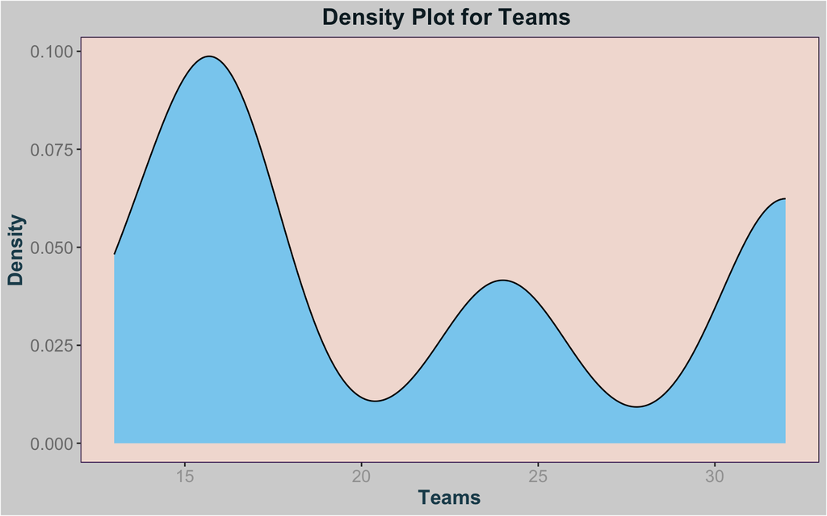

```r
## Exploring Density for numeric variables

density_1 <- ggplot(wc_2) +
  aes(x = teams) +
  geom_density(adjust = 0.5, fill = "#89cff0") +
  labs(
    x = "Teams",
    y = "Density",
    title = "Density Plot for Teams "
  ) +
  theme_wc()

density_1
```

As expected, the density of Games follows the same pattern as teams. As teams have increased so have the number of games. Th density for games is highest for above 60 games.

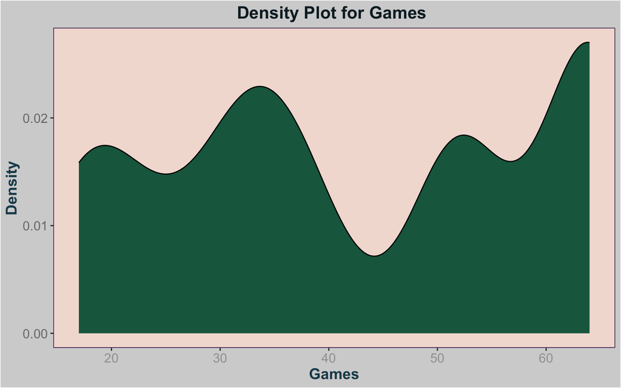

```r
density_2 <- ggplot(wc_2) +
  aes(x = games) +
  geom_density(adjust = 0.5, fill = "#19664E") +
  labs(
    x = "Games",
    y = "Density",
    title = "Density Plot for Games "
  ) +
  theme_wc()

density_2
```

## Correlation

Correlation of numeric variables is conducted using ggpairs function. This allows me to compare my numeric variables and their correlation or interactivity. The numeric variables of interest are teams, games, goals and attendance as seen below.

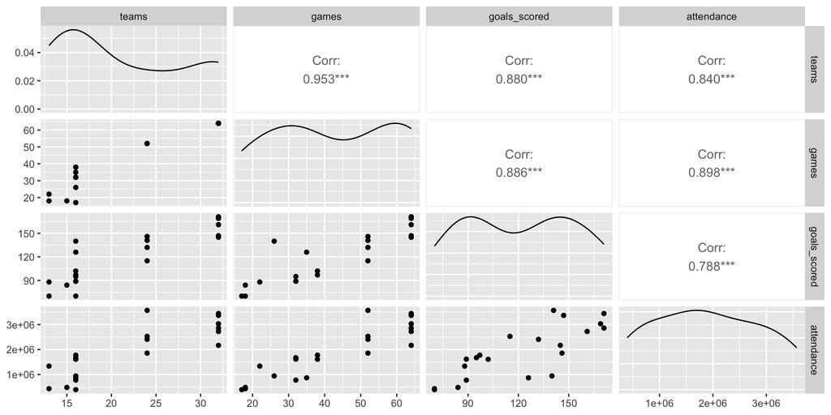

```r
# Correlation between key variables
corr <- wc_2 %>%  select(c("teams","games","goals_scored","attendance"))

# I use ggpairs to allow for visualizing correlation between teams, games, goals_scored & attendance
corr_gg <- ggpairs(corr)
corr_gg
```

## WORLD CUP DATA VISUAL ANALYSIS

1-A. **Teams participating & Games played Table**

This table shows the World Cup events from 1930. It shows the number of teams competing and games played. As seen the data is moving in the same direction. As teams particpation increases games played also increases.

```r
# Games played and average number of teams
ratings_table <- wc_2[,list( host, games, teams = (mean(teams))), by = year]
knitr::kable(ratings_table, caption="Games played and Teams")
```

Games played and Teams

| year | host | games | teams |
| --- | --- | --- | --- |
| 1930 | Uruguay | 18 | 13 |
| 1934 | Italy | 17 | 16 |
| 1938 | France | 18 | 15 |
| 1950 | Brazil | 22 | 13 |
| 1954 | Switzerland | 26 | 16 |
| 1958 | Sweden | 35 | 16 |
| 1962 | Chile | 32 | 16 |
| 1966 | England | 32 | 16 |
| 1970 | Mexico | 32 | 16 |
| 1974 | Germany | 38 | 16 |
| 1978 | Argentina | 38 | 16 |
| 1982 | Spain | 52 | 24 |
| 1986 | Mexico | 52 | 24 |
| 1990 | Italy | 52 | 24 |
| 1994 | USA | 52 | 24 |
| 1998 | France | 64 | 32 |
| 2002 | Japan, South Korea | 64 | 32 |
| 2006 | Germany | 64 | 32 |
| 2010 | South Africa | 64 | 32 |
| 2014 | Brazil | 64 | 32 |
| 2018 | Russia | 64 | 32 |

1-B. **Teams participating & Games played Graph**

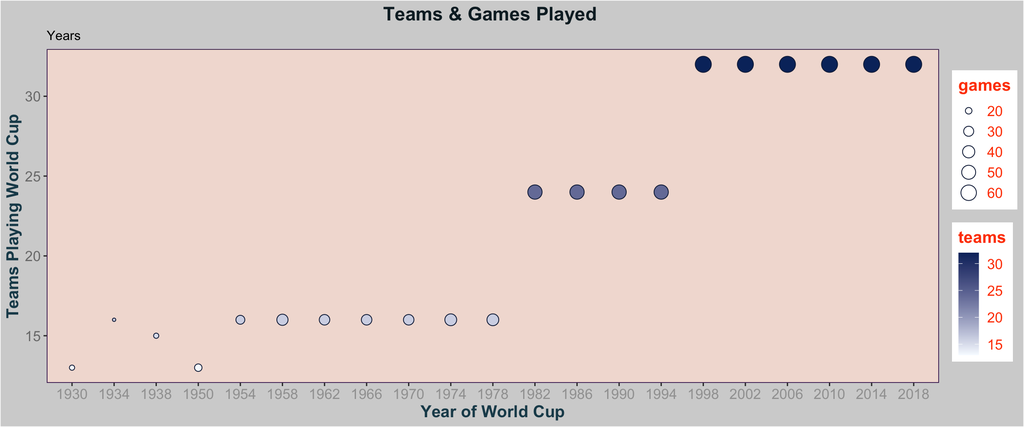

```r
g_1 <- ggplot(wc_2) +
  aes(x = year, y = teams, fill = teams, size = games) +
  geom_point(shape = "circle filled", colour = "#112446") +
  scale_fill_gradient(low = "#F7FBFF", high = "#08306B") +
  labs(
    x = "Year of World Cup",
    y = "Teams Playing World Cup",
    title = "Teams & Games Played ",
    subtitle = "Years"
  ) +
  theme(panel.background = element_rect(fill = '#ffe4c4', color = 'purple'),
          panel.grid.major = element_line(color = '#faebd7', linetype = 'dotted'),
          panel.grid.minor = element_line(color = '#008000', size = 2))+
  theme(axis.text.x = element_text(angle = 90, vjust = 0.5, hjust=1))+
  theme_wc()

g_1
```

The x axis is representing years the world cup was played while the y axis is showing teams particpation. Another important aspect is the size of the visualization which reoresents the games played. The circles get bigger as years and teams both increase.

2. **Goals according to World Cups**

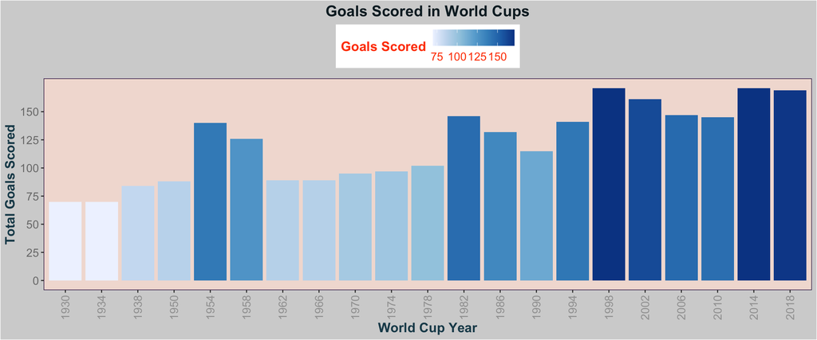

```r
g_2 <- ggplot(wc_2) +
  aes(x = year, fill = goals_scored, weight = goals_scored) +
  geom_bar() +
  scale_fill_distiller(palette = "Blues", direction = 1) +
  labs(
    x = "World Cup Year",
    y = "Total Goals Scored",
    title = "Goals Scored in World Cups",
    fill = "Goals Scored"
  ) +
  scale_y_continuous(breaks = seq(0,150, by = 25)) +
  theme_wc() +
  theme(legend.position = "top") +
  theme(axis.text.x = element_text(angle = 90, vjust = 0.5, hjust=1))

g_2
```

The most fascinating moment of a football match is when a goal is scored. So, which world cup saw the most goals from 1930 to 2018? As the bar chart shows, Goals scored are steadily increasing with some exceptions. Interestingly, 2018 world cup in Russia saw a slight fip comapred to 2014 world cup.

3. **Yearly Attendance at World Cup Events (1930-2018)**

[figure not shown]

```r
g_3 <- ggplot(wc_2, aes(x = year, y = attendance, fill = attendance)) + geom_bar(stat = 'identity') +
  theme_wc() +
  transition_states(year) +
  labs(title = 'Attendance at World Cup Events',
       subtitle = 'year: {closest_state}',
       y = 'Attendance') +
  theme(legend.position = "top" , legend.title = element_blank())

animate(g_3, end_pause = 10, fps = 5)

g_3
```

4. **Average Attendance (fill by average goals)**

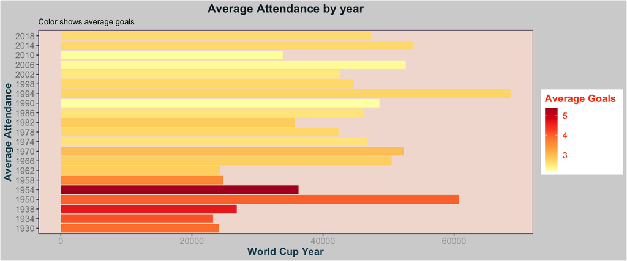

```r
g_4 <- ggplot(wc_2) +
  aes(x = year, y = average_attendance, fill = average_goals) +
  geom_col() +
  scale_fill_distiller(palette = "YlOrRd", direction = 1) +
  labs(
    x = "Average Attendance",
    y = "World Cup Year",
    title = "Average Attendance by year",
    subtitle = "Color shows average goals ",
    fill = "Average Goals "
  ) +
  coord_flip() +
  theme_wc()

g_4
```

One of the reasons why attendance will go up is because more games are being played. Therefore, I use my transformed variable which shows how average attendance varies per world cup event. Moreover, in this horizontal bar chart years are on the vertical while average attendance is on the horizontal. This shows that some years actually saw a drop in average attendance despite an increase in over all attendance. Moreover, average goals per game is also included in terms of intensity of color of the bar. As seen older world cups saw higher average goals per game (as seen in red). More recent world cups have lower goals per game played.

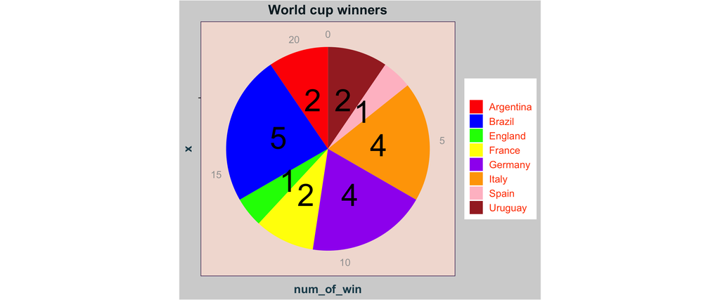

```r
colors_pie_chart <- c("red", "blue", "green", "yellow", "purple", "orange", "pink", "brown")

g_5 <- ggplot(winners_table, aes(x = "", y = num_of_win, fill = winner)) +
  geom_bar(width = 1, stat = "identity") +
  coord_polar("y", start = 0) +
  ggtitle("World cup winners") +
  labs(fill = "") +
  scale_fill_manual(values = colors_pie_chart) +
  geom_text(aes(label = num_of_win), position = position_stack(vjust = 0.5), size=13)+
  theme_wc()

g_5
```

A pie chart is a great measure to show the share or portion. Hence, I include the Winners data table for this visualization. Three large observations can be noticed immediately: Brazil at 5 World Cups and Germany & Italy at 4 . Then I notice some countries 2 & 1 world cup each.

6. **Goals by attendance category**

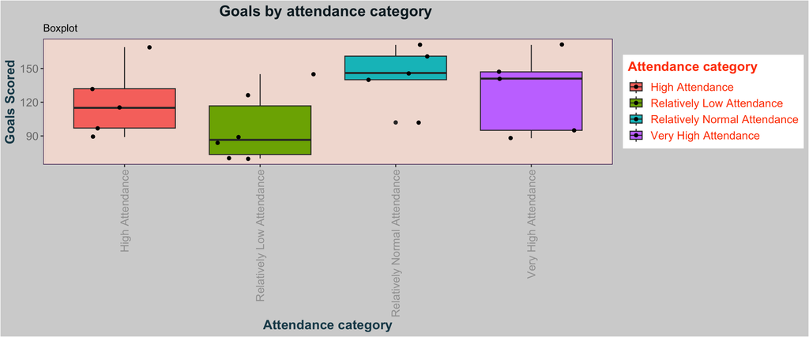

```r
g_6 <- ggplot(wc_2) +
 aes(x = attendance_categories, y = goals_scored, fill = attendance_categories) +
 geom_boxplot() +
 geom_jitter() +
 scale_fill_hue(direction = 1) +
 labs(x = "Attendance category", y = "Goals Scored",
 title = "Goals by attendance category ", subtitle = "Boxplot", fill = "Attendance category") +
 theme_wc()+
theme(axis.text.x = element_text(angle = 90, vjust = 0.5, hjust=1))

g_6
```

7. **MDS on Yearly Attendance**

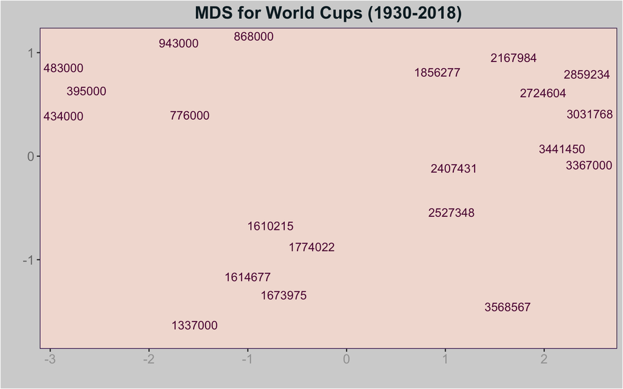

```r
#rm(mds_df)

# MDS data frame
mds_df <- data.frame(matrix(ncol = ncol(wc_2), nrow = 0))
# Relevant column names from wc_2 data table
colnames(mds_df) <- colnames(wc_2)
# Select the World Cup events by years
set.seed(1234)
for (i in 1930:2018){
  temp_df <- wc_2[year == i]
  mds_df <- rbind(mds_df, temp_df[sample(nrow(temp_df), 1),])
}

# put the names of the games as row names
mds_df <- column_to_rownames(mds_df, var = 'attendance')
# filter numeric variables
mds_df <- mds_df[, lapply(mds_df, is.numeric) == TRUE]

# MDS Analysis
mds_df <- cmdscale(dist(scale(mds_df)))
mds_df <- as.data.frame(mds_df)
mds_df$attendance <- rownames(mds_df)
rownames(mds_df) <- NULL

# Create MDS plot uisng #5d0d41 color
g_7 <- ggplot(data = mds_df, aes(x = V1, y = V2, label = attendance)) +
  geom_text_repel(colour="#5d0d41") +
  labs( x = '', y = '', title = 'MDS for World Cups (1930-2018)') +
  theme(axis.line=element_blank(),axis.text.x=element_blank(),
          axis.text.y=element_blank(),axis.ticks=element_blank()) +
   theme_wc()

g_7
```

MDS allows for relative distances to be incorporated. I use the years and audience as dimensions and create a visualization for MDS where the attendance is mapped and labelled as seen above.

8. **Day of Week and goals scored**

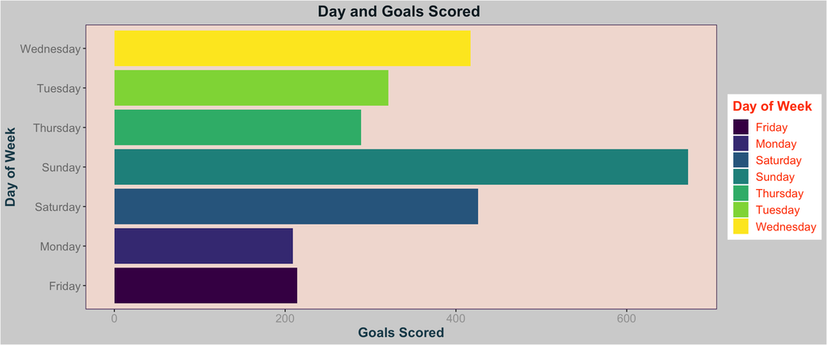

```r
g_8 <- ggplot(wc_1) +
  aes(x = dayofweek, y = total_goals, fill = dayofweek) +
  geom_col() +
  scale_fill_viridis_d(option = "viridis", direction = 1) +
  labs(
    x = "Day of Week",
    y = "Goals Scored",
    title = "Day and Goals Scored ",
    fill = "Day of Week"
  ) +
  coord_flip() +
  theme_wc()

g_8
```

Does goal scoring vary according to the day of week. As seen the games played on weekends have seen higher goals scored. Moreover, games on Sunday have a significantly higher number of goals scored compared to other days. The days are colored for easy readability.

9. **Host Country & Goals Scored**

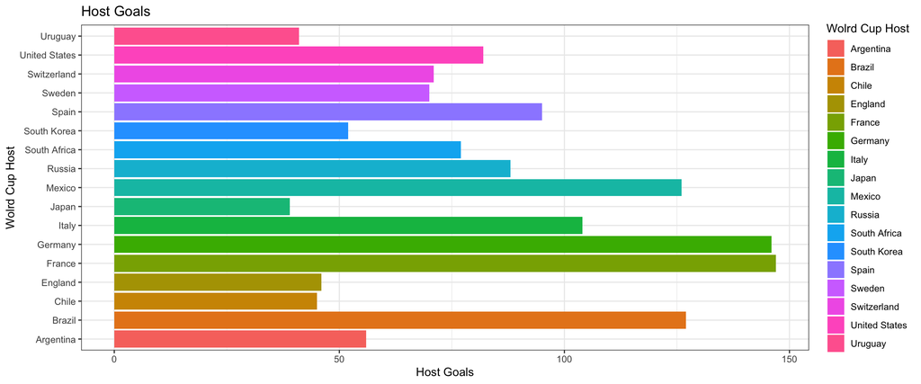

```r
g_9 <- ggplot(wc_1) +
  aes(x = country, y = home_goals, fill = country) +
  geom_col() +
  scale_fill_hue(direction = 1) +
  labs(
    x = "Wolrd Cup Host",
    y = "Host Goals",
    title = "Host Goals",
    fill = "Wolrd Cup Host"
  ) +
  coord_flip() +
  theme_bw()

g_9
```

Lastly, I also wanted to see how hosts have performed by goals scored.Hence, as seen above some host did tremendously well by scoring a high number of goals compared to other hosting countries. Germany, France, Mexico & Brazil have been high scoring hosts while some countries like Uruguay, Japan and England have been reletavily lower scoring hosts.